# Assignment3-Part2

Mengtong Zhang

4/3/2020

## Question 3

```r
library(wordVectors)
library(Rtsne)
library(tidytext)
library(tidyverse)
```

```r
if (!file.exists("cookbooks.zip")) {
  download.file("http://archive.lib.msu.edu/dinfo/feedingamerica/cookbook_text.zip","cookbooks.zip")
}
unzip("cookbooks.zip",exdir="cookbooks")
if (!file.exists("cookbooks.txt")) prep_word2vec(origin="cookbooks",destination="cookbooks.txt",lowercase=T,bundle_ngrams=1)

# Training a Word2Vec model
if (!file.exists("cookbook_vectors.bin")) {
  model = train_word2vec("cookbooks.txt","cookbook_vectors.bin",
                         vectors=100,threads=4,window=6,
                         min_count = 10,
                         iter=5,negative_samples=15)
} else{
    model = read.vectors("cookbook_vectors.bin")
    }
```

[output not shown]

[output cut: 53 more lines]

[output not shown]

1.  
To improve the quality of embedding, I would do stop words removal, stemming or lemmatization and text normalization.

2.  
I choose ‘salt’,‘pepper’ and ‘garlic’ as three ingresients. And pepper, salt, cayenne, garlic and maca are top 5 similar ingredients.

```r
# -- Select ingredient and cuisine --
ingredient = 'salt'
ingredient_2 = 'pepper'
ingredient_3 = 'garlic'
list_of_ingredients = c(ingredient, ingredient_2, ingredient_3)
# Set of closest words to "sage", "thyme","basil"
model %>% closest_to(model[[list_of_ingredients]],5)
```

```
##      word similarity to model[[list_of_ingredients]]
## 1  pepper                                  0.9007534
## 2    salt                                  0.8565778
## 3 cayenne                                  0.8440435
## 4  garlic                                  0.8355527
## 5    mace                                  0.7898229
```

3.  
Here we use t-SNE to see the relationships between set of words related with the three ingredients in question2.

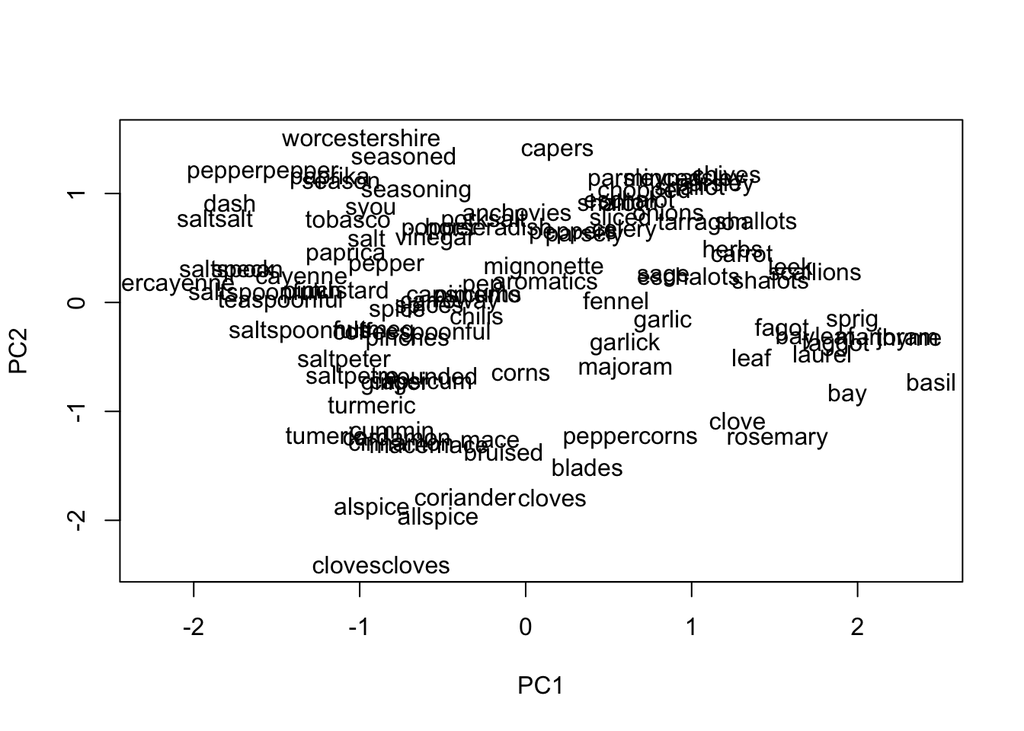

```r
n_words = 100
closest_ingredients = closest_to(model,model[[list_of_ingredients]], n_words)$word
surrounding_ingredients = model[[closest_ingredients,average=F]]
plot(surrounding_ingredients,method="pca")
```

```r
embedding = Rtsne(X = surrounding_ingredients, dims = 2,
                  perplexity = 4,
                  theta = 0.5,
                  eta = 10,
                  pca = TRUE, verbose = TRUE,
                  max_iter = 2000)
```

[output not shown]

```r
embedding_vals = embedding$Y
rownames(embedding_vals) = rownames(surrounding_ingredients)
```

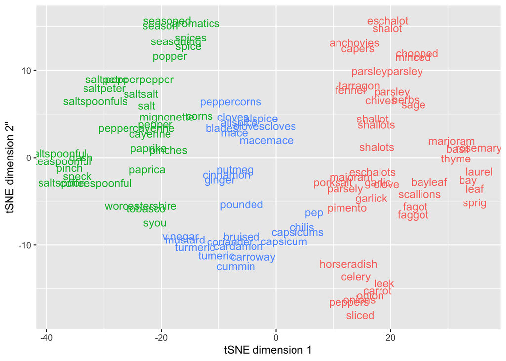

```r
embedding_vals = embedding$Y
rownames(embedding_vals) = rownames(surrounding_ingredients)
set.seed(10)
n_centers = 3
clustering = kmeans(embedding_vals,centers=n_centers,
                    iter.max = 5)

# Setting up data for plotting
embedding_plot = tibble(x = embedding$Y[,1],
                        y = embedding$Y[,2],
                        labels = rownames(surrounding_ingredients)) %>%
  bind_cols(cluster = as.character(clustering$cluster))

# Visualizing TSNE output
ggplot(aes(x = x, y=y,label = labels, color = cluster), data = embedding_plot) +
  geom_text() +xlab('tSNE dimension 1') +ylab('tSNE dimension 2"')+theme(legend.position = 'none')
```

```r
# Topics produced by the top 3 words
sapply(sample(1:n_centers,n_centers),function(n) {
  names(clustering$cluster[clustering$cluster==n][1:10])
})
```

```
##       [,1]       [,2]          [,3]
##  [1,] "vinegar"  "salt"        "chopped"
##  [2,] "nutmeg"   "pepper"      "parsley"
##  [3,] "cinnamon" "teaspoonful" "onion"
##  [4,] "cloves"   "season"      "onions"
##  [5,] "mustard"  "cayenne"     "celery"
##  [6,] "mace"     "pinch"       "sliced"
##  [7,] "ginger"   "seasoning"   "herbs"
##  [8,] "pounded"  "seasoned"    "minced"
##  [9,] "allspice" "spices"      "bay"
## [10,] "bruised"  "spice"       "leaf"
```

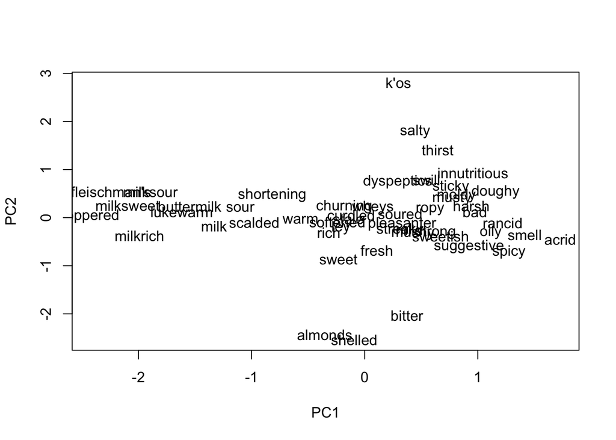

```r
list_of_ingredients = c('salty','sour','bitter')
closest_ingredients = closest_to(model,model[[list_of_ingredients]], 50)$word
surrounding_ingredients = model[[closest_ingredients,average=F]]
plot(surrounding_ingredients,method="pca")
```

Not quite make sense. Because there are supposed to be 3 obvious different clusters. Then we perform t-SNE.

```r
embedding = Rtsne(X = surrounding_ingredients, dims = 2,
                  perplexity = 4,
                  theta = 0.5,
                  eta = 10,
                  pca = TRUE, verbose = TRUE,
                  max_iter = 2000)
```

[output not shown]

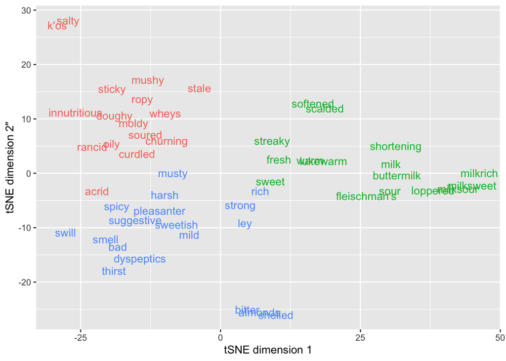

```r
embedding_vals = embedding$Y
rownames(embedding_vals) = rownames(surrounding_ingredients)
set.seed(10)
n_centers = 3
clustering = kmeans(embedding_vals,centers=n_centers,
                    iter.max = 5)

# Setting up data for plotting
embedding_plot = tibble(x = embedding$Y[,1],
                        y = embedding$Y[,2],
                        labels = rownames(surrounding_ingredients)) %>%
  bind_cols(cluster = as.character(clustering$cluster))

# Visualizing TSNE output
ggplot(aes(x = x, y=y,label = labels, color = cluster), data = embedding_plot) +
  geom_text() +xlab('tSNE dimension 1') +ylab('tSNE dimension 2"')+theme(legend.position = 'none')
```

```r
# Topics produced by the top 3 words
sapply(sample(1:n_centers,n_centers),function(n) {
  names(clustering$cluster[clustering$cluster==3][1:10])
})
```

```
##       [,1]      [,2]      [,3]
##  [1,] "rich"    "rich"    "rich"
##  [2,] "almonds" "almonds" "almonds"
##  [3,] "strong"  "strong"  "strong"
##  [4,] "bitter"  "bitter"  "bitter"
##  [5,] "bad"     "bad"     "bad"
##  [6,] "shelled" "shelled" "shelled"
##  [7,] "smell"   "smell"   "smell"
##  [8,] "mild"    "mild"    "mild"
##  [9,] "thirst"  "thirst"  "thirst"
## [10,] "musty"   "musty"   "musty"
```

5.

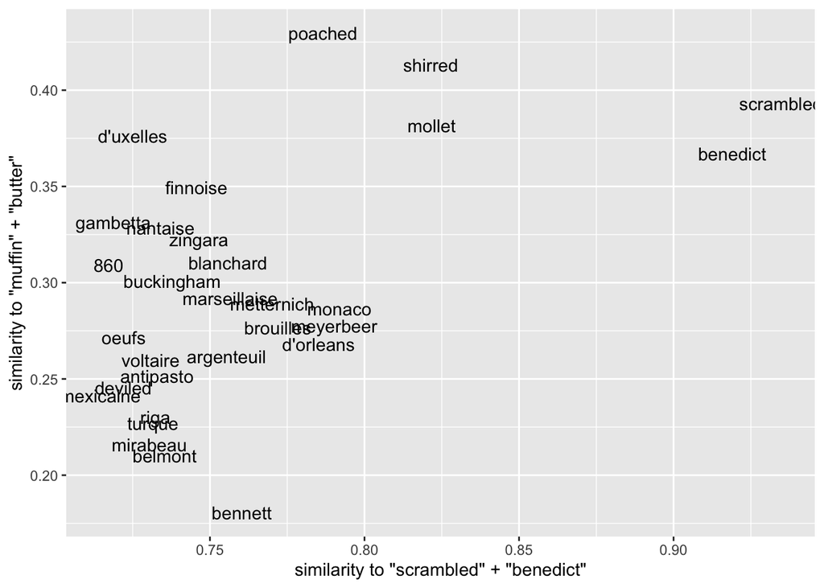

```r
top_evaluative_words = model %>%
  closest_to(~ "scrambled"+"benedict",n=30)
goodness = model %>%
  closest_to(~ "scrambled"-"benedict",n=Inf)
taste = model %>%
  closest_to(~ "muffin" + "butter", n=Inf)

top_evaluative_words %>%
  inner_join(goodness) %>%
  inner_join(taste) %>%
  ggplot() +
  geom_text(aes(x=`similarity to "scrambled" + "benedict"`,
                y=`similarity to "muffin" + "butter"`,
                label=word))
```

7.  
Here we need the package ngram.

```r
library(ngram)
text = readLines('/Users/zmt/Desktop/cookbooks.txt')
txt = ''
for (i in text){txt = concatenate(txt,i)}
```

```r
txt = preprocess (txt ,case ="lower", remove.punct = TRUE )
```

```r
ng <- ngram (txt , n =2)
```

The list is as shown below:

```r
cat('Top ten are','\n')
```

```
## Top ten are
```

```r
get.phrasetable(ng)[1:10,]
```

```
##       ngrams  freq        prop
## 1    of the  61141 0.005835815
## 2    in the  46763 0.004463457
## 3      in a  45059 0.004300812
## 4    with a  29628 0.002827947
## 5    to the  24058 0.002296299
## 6     it is  23983 0.002289141
## 7  a little  23460 0.002239221
## 8      of a  22043 0.002103970
## 9  with the  20208 0.001928823
## 10    and a  20000 0.001908969
```

## Question 4

#### Part1

```r
dat = read.csv('/Users/zmt/Desktop/kernel_regression_1.csv')
set.seed(129)
idx = 990:1001
x_observed = dat$x[-idx]
f = dat$y[-idx]
x_prime = dat$x
K = function(x,x_prime,l){
  d = sapply(x,FUN=function(x_in)(x_in-x_prime)^2)
  return(t(exp(-1/(2*l)*d)))
}
mu=0
mu_star=0
l=10
K_f = K(x_observed,x_observed,l)
for (i in 1:dim(K_f)[1]){K_f[i,i]=K_f[i,i]+0.000001}
K_star = K(x_observed,x_prime,l)
K_starstar = K(x_prime,x_prime,l)
mu_star = mu_star + t(K_star)%*%solve(K_f)%*%(f-mu)
Sigma_star = K_starstar - t(K_star)%*%t(solve(K_f))%*%K_star
```

2. Note that here we only take the kernel of log likelihood (So it can be positive).
   $$L(y_1,...,y_n) = \frac{1}{(2\pi)^n|\Sigma|}e^{-(y-\mu)^{T}\Sigma^{-1}(y-\mu)}$$
   $$logLL \propto -log(|\Sigma|)-(y-\mu)^{T}\Sigma^{-1}(y-\mu)$$

```r
for (ll in c(1,0.1,0.01,0.00001)){
mu=0
mu_star=0
l=ll
K_f = K(x_observed,x_observed,l)
# Add little perbutation to make K_f inversable
for (i in 1:dim(K_f)[1]){K_f[i,i]=K_f[i,i]+0.000001}
K_star = K(x_observed,x_prime,l)
K_starstar = K(x_prime,x_prime,l)
mu_star = mu_star + t(K_star)%*%solve(K_f)%*%(f-mu)
Sigma_star = K_starstar - t(K_star)%*%t(solve(K_f))%*%K_star
Sigma_star_test = Sigma_star[idx,idx]
#for (i in 1:dim(Sigma_star)[1]){Sigma_star[i,i]=Sigma_star[i,i]+1}
# Here only take the kernel of likelihood
#logLL = log(dmvnorm(dat$y[idx],mean = mu_star[idx], sigma=Sigma_star_test))
logLL = -log(det(Sigma_star_test)) - t(dat$y[idx]-mu_star[idx])%*%solve(Sigma_star_test)%*%(dat$y[idx]-mu_star[idx])
cat('theta=',ll,'Negative Log Likelihood is',-logLL,'\n')}
```

```
## theta= 1 Negative Log Likelihood is NaN
```

```
## theta= 0.1 Negative Log Likelihood is NaN
```

```
## theta= 0.01 Negative Log Likelihood is NaN
## theta= 1e-05 Negative Log Likelihood is 7.944166
```

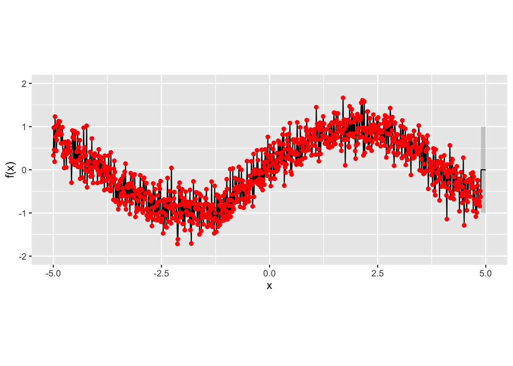

```r
plot_gp = tibble(x = x_prime,
                 y = mu_star %>% as.vector(),
                 sd_prime = sqrt(diag(Sigma_star)))

# Plotting values
ggplot(aes(x = x, y = y), data = plot_gp) +
  geom_line()+
  geom_ribbon(aes(ymin = y-sd_prime,ymax = y+sd_prime), alpha = 0.2)+
  geom_point(aes(x =x , y= y), data = tibble(x = x_observed, y = f),
             color = 'red') +
  xlim(c(-5,5))+ylim(c(-2,2))+
  coord_fixed(ratio = 1) +ylab('f(x)')
```

#### Part 2

```r
dat = read.csv('/Users/zmt/Desktop/kernel_regression_2.csv')
set.seed(129)
idx = 990:1001
x_observed = dat$x[-idx]
f = dat$z[-idx]
x_prime = dat$x
K = function(x,x_prime,l){
  d = sapply(x,FUN=function(x_in)(x_in-x_prime)^2)
  return(t(exp(-1/(2*l)*d)))
}
mu=0
mu_star=0
l=10
K_f = K(x_observed,x_observed,l)
for (i in 1:dim(K_f)[1]){K_f[i,i]=K_f[i,i]+0.000001}
K_star = K(x_observed,x_prime,l)
K_starstar = K(x_prime,x_prime,l)
mu_star = mu_star + t(K_star)%*%solve(K_f)%*%(f-mu)
Sigma_star = K_starstar - t(K_star)%*%t(solve(K_f))%*%K_star
```

```r
for (ll in c(0.1,0.01,0.00001)){
mu=0
mu_star=0
l=ll
K_f = K(x_observed,x_observed,l)
# Add little perbutation to make K_f inversable
for (i in 1:dim(K_f)[1]){K_f[i,i]=K_f[i,i]+0.000001}
K_star = K(x_observed,x_prime,l)
K_starstar = K(x_prime,x_prime,l)
mu_star = mu_star + t(K_star)%*%solve(K_f)%*%(f-mu)
Sigma_star = K_starstar - t(K_star)%*%t(solve(K_f))%*%K_star
Sigma_star_test = Sigma_star[idx,idx]
logLL = -log(det(Sigma_star_test)) - t(dat$y[idx]-mu_star[idx])%*%solve(Sigma_star_test)%*%(dat$y[idx]-mu_star[idx])
cat('theta=',ll,'Negative Log Likelihood is',-logLL,'\n')}
```

```
## theta= 0.1 Negative Log Likelihood is 1960834402
## theta= 0.01 Negative Log Likelihood is 6756231175
## theta= 1e-05 Negative Log Likelihood is 8570229749
```

$\theta=0.1$ is the best choice.

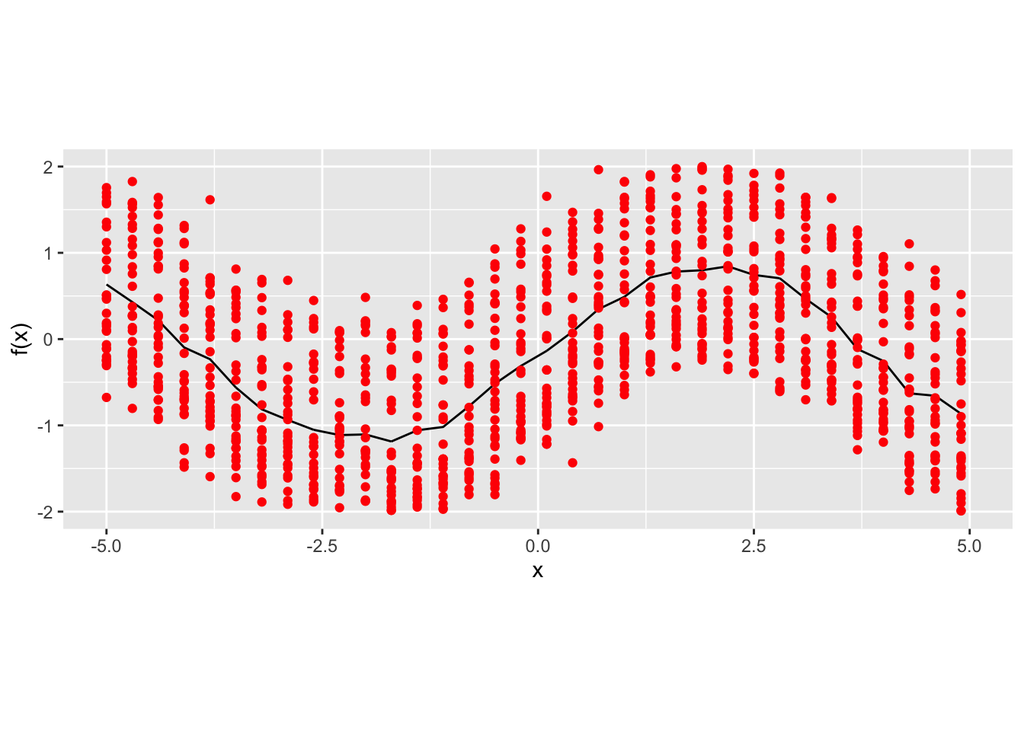

```r
plot_gp = tibble(x = x_prime,
                 y = mu_star %>% as.vector(),
                 sd_prime = sqrt(diag(Sigma_star)))

# Plotting values
ggplot(aes(x = x, y = y), data = plot_gp) +
  geom_line()+
  geom_ribbon(aes(ymin = y-sd_prime,ymax = y+sd_prime), alpha = 0.2)+
  geom_point(aes(x =x , y= y), data = tibble(x = x_observed, y = f),
             color = 'red') +
  xlim(c(-5,5))+ylim(c(-2,2))+
  coord_fixed(ratio = 1) +ylab('f(x)')
```